# 2 FPGA 开发环境配置

## 2.1 Arty A7-100T CFU-playground 环境配置

资料:

- [官方 CFU Playground Setup Guide](https://cfu-playground.readthedocs.io/en/latest/index.html), [官方 CFU Github](https://github.com/google/CFU-Playground)
- [My Forked CFU Playground](https://github.com/Marcobisky/CFU-Playground)

### 2.1.1 MacOS Docker 部署

以下是本人在 MacOS 试过的两种失败的方法, 供参考:

**MacOS 原生部署 (未成功)**

官方 [Setup Guide](https://cfu-playground.readthedocs.io/en/latest/setup-guide.html) 不适用于 MacOS, 本教程可以配合官方教程. 以下是在 14-inch MacBook Pro (M2 pro) 上我执行过的命令, 可能有不必要的步骤. 另外我之前安装过一些工具如 `make`, `brew`, `openocd` 等, 如有漏掉的步骤请用 `brew` 自行安装.

1. CFU 环境配置

   ```bash
   git clone https://github.com/google/CFU-Playground.git
   cd CFU-Playground
   # Check necessary tools
   which gcc
   which make
   which brew
   brew install openocd ccache verilator ninja libusb libftdi
   which expect
   ```

   将 `scripts/setup` 中的 line 58-60 替换为:

   ```bash
   # Check for libusb development libraries
   if [[ "$OSTYPE" == "darwin"* ]]; then
       # macOS: check for Homebrew libusb
       if ! brew list libusb >/dev/null 2>&1 || ! brew list libftdi >/dev/null 2>&1; then
           missing+=(libusb libftdi)
       fi
   else
       # Linux: check for apt packages
       if ! (apt list -i | grep libusb-1.0-0-dev) ; then
           missing+=(libusb-1.0-0-dev libftdi1-dev)
       fi
   fi
   ```

   再运行:

   ```bash
   # Should end up "Setup complete"
   ./scripts/setup
   ```

   `Amaranth` 能让你用 `Python` 写硬件描述语言, 我们暂时不安装.
2. FPGA 开源工具链 SymbiFlow 配置

   MacOS 上会遇到以下问题:
   - dfu-util 包不可用
   - flterm 包不可用
   - Python 3.7 不支持

   执行:

   ```bash
   brew install dfu-util yosys
   ```

   将 `conf/environment-symbiflow.yml` 中替换为:

   ```yaml
   name: cfu-symbiflow
   channels:
   - defaults
   - conda-forge
   dependencies:
   # Basic Python packages that should be available
   - lxml
   - simplejson
   - intervaltree
   - json-c
   - libevent
   - python=3.9
   - pip
   - pip:
       - -r ./requirements-symbiflow.txt
   ```

   然后运行:

   ```bash
   rm -rf env/symbiflow && make install-sf
   ```

   出现以下输出时表示安装成功:

   ```
   Done installing SymbiFlow.  To enter the environment, type 'make enter-sf', which creates a new subshell, and 'exit' when done.
   ```

   测试环境:

   ```bash
   make enter-sf
   exit
   ```

   以上方法会在执行 `zsh make prog TARGET=digilent_arty USE_SYMBIFLOW=1`

   时出现错误, 因为我们删掉了很多 `python` 依赖. 这些依赖在 `litex-hub` 源里面没有 `osx-arm64` 的版本!!!

**MacOS 虚拟机部署 (未成功)**

CFU playground 里的 `environment-symbiflow` 里的很多依赖 (比如 `dfu-util` 和 `flterm` 等, 可以在 [Anaconda](https://anaconda.org) 里面搜索你需要的包) 只支持 `linux-64` 版本, M 芯片的 MacOS 上的 PD 好像只能安装 `linux-aarch64` 架构的虚拟机.

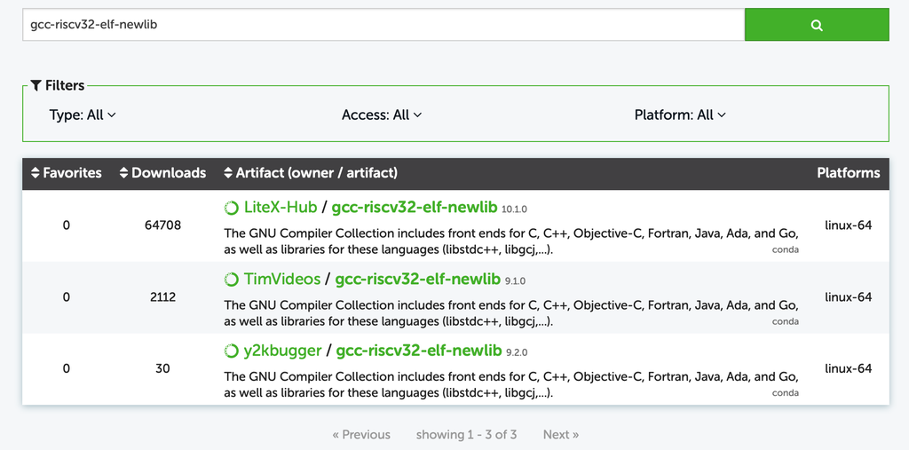

`gcc-riscv32-elf-newlib` 只支持 `linux-64`

在你安装的虚拟机终端执行:

```bash
arch
```

不能是 `aarch64` 才行, 需要是 `x86_64` 才能安装 `linux-64` 架构的包!!!

我们利用 Docker 来搭建 CFU Playground 环境, 这样可以避免 MacOS 上的架构问题. 自行安装 Docker, 然后需要稍微改一下 `scripts/Dockerfile` 和 `scripts/setup` 脚本. 可以直接 clone 我的 fork:

```bash
git clone https://github.com/Marcobisky/CFU-Playground.git
```

然后切换到 `macos-env` 分支, 在 `CFU-Playground` 目录下执行:

```bash
# Takes around 20 min
docker build -t cfu-playground --platform linux/amd64 ./scripts
```

查看镜像:

```bash
docker images
```

逐条执行, 其中 `-v $(pwd):/workspace` 表示**当前目录 (宿主机)**挂载到容器的 `/workspace` 目录中 (数据共享通道). 但是以下命令不要在 `/workspace` 里面执行:

```bash
docker run -it -v $(pwd):/workspace cfu-playground bash
./scripts/setup
# Takes around 9 min
make install-sf
make enter-sf
cd proj/proj_template
make clean
make bitstream TARGET=digilent_arty USE_SYMBIFLOW=1
```

如果没报错, 恭喜你成功生成了比特流文件! 当你没插上板子的时候如果按照官方运行 `make prog TARGET=digilent_arty USE_SYMBIFLOW=1` 会报错:

```bash
Error: libusb_init() failed with LIBUSB_ERROR_OTHER

Traceback (most recent call last):
  File "./common_soc.py", line 57, in <module>
    main()
  File "./common_soc.py", line 53, in main
    workflow.run()
  File "/CFU-Playground/soc/board_specific_workflows/general.py", line 127, in run
    self.load(soc, soc_builder)
  File "/CFU-Playground/soc/board_specific_workflows/general.py", line 116, in load
    prog.load_bitstream(bitstream_filename)
  File "/CFU-Playground/third_party/python/litex/litex/build/openocd.py", line 27, in load_bitstream
    self.call(["openocd", "-f", config, "-c", script])
  File "/CFU-Playground/third_party/python/litex/litex/build/generic_programmer.py", line 101, in call
    raise OSError(msg)
OSError: Error occured during OpenOCD's call, please check:
- OpenOCD installation.
- Access permissions.
- Hardware and cable.
- Bitstream presence.
```

即 `libusb_init()` 函数初始化错误. 事实上不可能通过 Docker 给开发版烧录, MacOS 环境有一个隔离层, GPT 如是说:

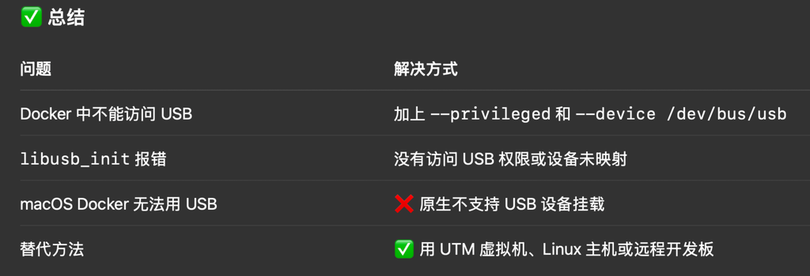

不可能通过 Docker 给开发版烧录

可以用两次 `exit` 退出容器 (第一次只会退出 `enter-sf` 的子 shell).

如果要交互式运行已经存在的容器 (例如叫 `romantic_austin`), 运行:

```bash
docker start -ai romantic_austin
```

### 2.1.2 Ubuntu 24.04 实体机部署

我们用 Arty A7-100T 开发板.

具体运行步骤几乎与 MacOS 一样, 直接按照 [Setup Guide](https://cfu-playground.readthedocs.io/en/latest/setup-guide.html) 执行即可. 如果 `make install-sf` 报错:

```bash
wget -qO- https://storage.googleapis.com/symbiflow-arch-defs/artifacts/prod/foss-fpga-tools/symbiflow-arch-defs/continuous/install/20220729-181657/symbiflow-arch-defs-install-xc7-7833050.tar.xz | tar -xJC env/symbiflow/xc7/install
xz: (stdin): File format not recognized
tar: Child returned status 1
tar: Error is not recoverable: exiting now
make: *** [Makefile:58: install-sf] Error 2
```

仅仅是网络连接的问题, 请把科学上网 (如 Clash Verge) 安装上 Service Mode, 然后打开 Tun Mode. 把 `Makefile` 中 63-65 行的三个 `wget` 改成 `curl` 的写法. 在我的 fork 上已经更改, 直接 clone 即可:

```bash
git clone https://github.com/Marcobisky/CFU-Playground.git
```

让后切换到 `ubuntu-env` 分支, 即可跑通 `make install-sf`.

如果没插入开发板, 运行:

```bash
make bitstream TARGET=digilent_arty USE_SYMBIFLOW=1
```

即可跑通. 若已经插入开发板, 则运行:

```bash
make prog TARGET=digilent_arty USE_SYMBIFLOW=1 EXTRA_LITEX_ARGS='--variant=a7-100'
make load BUILD_JOBS=4 TARGET=digilent_arty EXTRA_LITEX_ARGS='--variant=a7-100'
```

**Important**

如果你跟我一样用的是 Arty A7-100T **而不是 35T**, 必须加上 `EXTRA_LITEX_ARGS='--variant=a7-100'` 参数 (见 [CFU Wiki](https://github.com/google/CFU-Playground/wiki/Supported-Boards)), 否则程序会卡在 `make load` 这一步, 并且会一直卡在这里 (按 enter 也没有用, 只能两下 Ctrl+C 退出):

```bash
/home/merlin/fpga/CFU-Playground/soc/bin/litex_term --speed 3686400  --kernel /home/merlin/fpga/CFU-Playground/proj/proj_template/build/software.bin /dev/ttyUSB1
```

当然卡在这里还有可能是其它问题: 见 [Issue #787](https://github.com/google/CFU-Playground/issues/787), [Issue #775](https://github.com/google/CFU-Playground/issues/775).

## 2.2 iCESugar-UP5K 开发环境配置

资料:

- [官方 icesugar](https://github.com/wuxx/icesugar): 重要! 用它来学习 iCESugar-UP5K 开发板.
- [My TinyML Repo](https://github.com/Marcobisky/TinyML)

### 2.2.1 MacOS 部署

如果你没有安装 `Homebrew` 包管理器, 请先安装 (会自动先安装 Xcode 命令行工具, 输入密码的过程不可见, 装完了要按照提示将 `brew` 添加到 `PATH` 中):

```bash
/bin/bash -c "$(curl -fsSL https://raw.githubusercontent.com/Homebrew/install/HEAD/install.sh)"
```

直接按 [nextpnr](https://github.com/YosysHQ/nextpnr?tab=readme-ov-file#) 中的 next-pnr-ice40 的说明安装即可. 大致为以下几个命令 (可能有遗漏), 逐条执行:

```bash
git clone https://github.com/YosysHQ/nextpnr.git
cd nextpnr
# May not be successful immediately
brew install cmake python boost eigen
git submodule update --init --recursive
brew install boost
# These two lines just to make sure dependencies are installed
brew install eigen
mkdir -p build && cd build
cmake .. -DARCH=ice40 -DICESTORM_INSTALL_PREFIX=/usr -DICEBOX_DATADIR=/usr/share/fpga-icestorm/chipdb
# May be some error, please solve by yourself using GPT.
make -j$(nproc)
# Check if nextpnr-ice40 is built
ls -la nextpnr-ice40
# Install placing, routing and binary database format files
sudo make install
```

### 2.2.2 Ubuntu 24.04 实体机部署

按 [nextpnr](https://github.com/YosysHQ/nextpnr?tab=readme-ov-file#) 中的 next-pnr-ice40 的说明安装即可. i.e., 逐条执行:

```bash
git clone https://github.com/YosysHQ/nextpnr.git
sudo apt update
sudo apt install libboost-all-dev libboost-filesystem-dev libboost-program-options-dev libboost-iostreams-dev libboost-system-dev libboost-thread-dev libeigen3-dev
git submodule update --init --recursive
mkdir -p build && cd build
sudo apt install fpga-icestorm
cmake .. -DARCH=ice40 -DICESTORM_INSTALL_PREFIX=/usr -DICEBOX_DATADIR=/usr/share/fpga-icestorm/chipdb
make -j$(nproc)
# Check if nextpnr-ice40 is built
ls -la nextpnr-ice40
# Install placing, routing and binary database format files
sudo make install
```

### 2.2.3 blink 例子测试

用 [My TinyML Repo](https://github.com/Marcobisky/TinyML) 的 `blink` 例子测试一下. 将 iCESugar 开发板连接到电脑 (注意不要用 JTAG 调试器, 直接用 C 口连接电脑). 按以下方式生成比特流 `blink.bin`:

```bash
cd iCESugar/examples/blink
make
```

在 Ubuntu 上可通过以下方式烧录:

```bash
sudo icesprog blink.bin
```

在 MacOS 上, 好像安装不上 `icesprog`, 直接将 `blink.bin` 拷贝到 iCESugar 虚拟磁盘上即可烧录.

**烧录方法注意**

1. Ubuntu

   一定要用 `sudo icesprog`! 单用 `iceprog` 会报错:

   ```bash
   init..
   Can't find iCE FTDI USB device (vendor_id 0x0403, device_id 0x6010 or 0x6014).
   ABORT.
   ```

2. MacOS

   注意 MacOS 上 `iceprog` 和 `icesprog` 烧录工具都不能用!

   MacOS 上的烧录工具 `iceprog` 不能识别到 FTDI 设备, 这可能是 MacOS 上的 USB 设备权限问题, 本人尝试过安装 [FTDI 驱动](https://ftdichip.com/drivers/d2xx-drivers/), 安装手册见[这里](https://ftdichip.com/document/installation-guides/). 安装的时候如果不小心点了 `OK`, 安装程序会提示 “awaiting approval”, 解决方法见[这里](https://www.reddit.com/r/Baofeng/comments/1i4b9t0/ftdi_driver_install_issue_on_mac/). 但是安装好了, Mac 还是识别不到开发板.